# 上級マクロ経済学II

第5回 2期間モデルと世代重複モデル

Author

荻巣嘉高

# 1 オイラー方程式

## モデルの概要

- 家計が2期間生存する．
  - 2期間の消費$c_1, c_2$のために，最適な貯蓄$s$を選択
  - 労働は非弾力的に供給
- 企業はいくつかの設定の仕方があるが，今回は考慮しない．
- 基本モデルでは政府はなし．
- 断りがない限り，実物経済のみを考慮（物価・貨幣は考慮しない）．

2期間モデルはライフサイクルモデルの一種として考えられる．

## 家計

効用関数を次のように仮定．
$$U(c_1, c_2) = u (c_1) + \beta u (c_2)$$
$\beta \in (0,1)$：割引因子

予算制約は，
$$\begin{aligned}
c_1 + s &= y_1 \\
c_2 &= y_2 + (1+r) s
\end{aligned}$$

## オイラー方程式

$$\frac{u'(c_2)}{u' (c_1)} = \frac{1}{\beta (1+r)}$$

- $\beta = \frac{1}{1+\rho}$とすれば（$\rho$：割引率），$\frac{u'(c_2)}{u' (c_1)} = \frac{1+\rho}{1+r}$．
- 簡単化のために$u(c) = \log c$を仮定すれば，

$$\frac{c_1}{c_2} = \frac{1+\rho}{1+r}$$

## 貯蓄の決定

$$\begin{aligned}
c_1 &= \frac{1+\rho}{2+\rho} \left( y_1 + \frac{y_2}{1+r} \right) \\
c_2 &= \frac{1+r}{2+\rho} \left( y_1 + \frac{y_2}{1+r} \right) \\
s &= y_1 - c_1 = \frac{1+\rho}{2+\rho} \left( \frac{y_1}{1+\rho} + \frac{y_2}{1+r} \right)
\end{aligned}$$

- 経済全体での貯蓄は，$s$に人口をかけてやればOK．

# 2 世代重複モデル（Overlapping Generations Model; OLG model）

## 世代重複モデル

- 各世代は2期間（若年期・老年期）生存する．
  - 2期間モデルの拡張版と考えられる．
- ある期には，前の世代の老年期と，新しい世代の若年期が同時に存在する．

[figure not shown]

## Basic setup

- 完全競争かつ価格は伸縮的に調整される．

家計

- 2期間（若年期・老年期）生存する代表的家計
- 若年期（$\rm{y}$），老年期（$\rm{o}$）の消費から効用を得る．
- 若年期は労働・消費・貯蓄，老年期は貯蓄の取り崩しで生活
- 各家計1単位の労働力を供給
  - 人口$L_t$は人口成長率$n$の割合で成長

企業

- 無限期間生存する代表的企業
- 一般的な生産関数を仮定し，各期のフロー利潤を最大化するように行動．
  - 資本$K_t$，労働$L_t$を用いて生産，対価として利子$r_t$，賃金$w_t$を各期支払う．

## 家計

効用関数を次のように仮定．
$$\max U(c_t^{\rm{y}}, c_{t+1}^{\rm{o}}) = u (c_t^{\rm{y}}) + \beta u (c_{t+1}^{\rm{o}})$$
$$s.t.\left\{ \begin{aligned}
c_t^{\rm{y}} + s_t &= w_t \\
c_{t+1}^{\rm{o}} &= (1+r_{t+1}) s_t
\end{aligned}\right.$$
$\beta \in (0,1)$：割引因子

瞬時的効用関数を対数形に仮定すれば，オイラー方程式は
$$\frac{c_t^{\rm{y}}}{c_{t+1}^{\rm{o}}} = \frac{1+\rho}{1+r_{t+1}}$$

一人当たりの貯蓄は
$$s_t = \frac{1}{2+\rho} w_t$$

## 企業

コブ・ダグラス型の生産関数を設定．
$$Y_t = F(K_t, L_t) = A K_t^{\alpha} L_t^{1-\alpha}$$

- 一人当たりは$f(k_t) = Ak_t^{\alpha}$

利潤最大化の一階の条件から，
$$\begin{aligned}
\frac{\partial Y_t}{\partial K_t} &= \alpha A (k_t)^{\alpha-1} = f'(k_t) = R_t \\
\frac{\partial Y_t}{\partial L_t} &= (1-\alpha) A (k_t)^{\alpha} = f(k_t) - k_t f'(k_t) = w_t
\end{aligned}$$

- $R_t = 1+r_t$は祖利子率．
- 価格が調整されて市場が精算される（=経済が均衡にある）．

## 資本蓄積

今期の投資がそのまま次期の資本ストックになる．$I_t=S_t$より，
$$K_{t+1} = s_t L_t$$

一人当たりに直すと，
$$k_{t+1} = \frac{s_t}{1+n} = \frac{w_t}{(1+n)(1+\rho)}$$

結果的に，経済の均衡での資本蓄積は次の差分方程式で記述される．
$$k_{t+1} = \frac{A (1-\alpha)}{(1+n)(1+\rho)} k_t^{\alpha}$$

## 位相図と定常状態

- 縦軸に$k_{t+1}$，横軸に$k_t$を取って描いた図を位相図という．
- 定常状態は$k_{t+1} = k_t$．
  - 45度線との交点が定常状態．
    $$k^* = \left[ \frac{A (1-\alpha)}{(1+n)(1+\rho)}\right]^{\frac{1}{1-\alpha}}$$
- 定常状態での一人当たり生産（所得）は
  $$y^* = A \left[ \frac{A (1-\alpha)}{(1+n)(1+\rho)}\right]^{\frac{\alpha}{1-\alpha}}$$

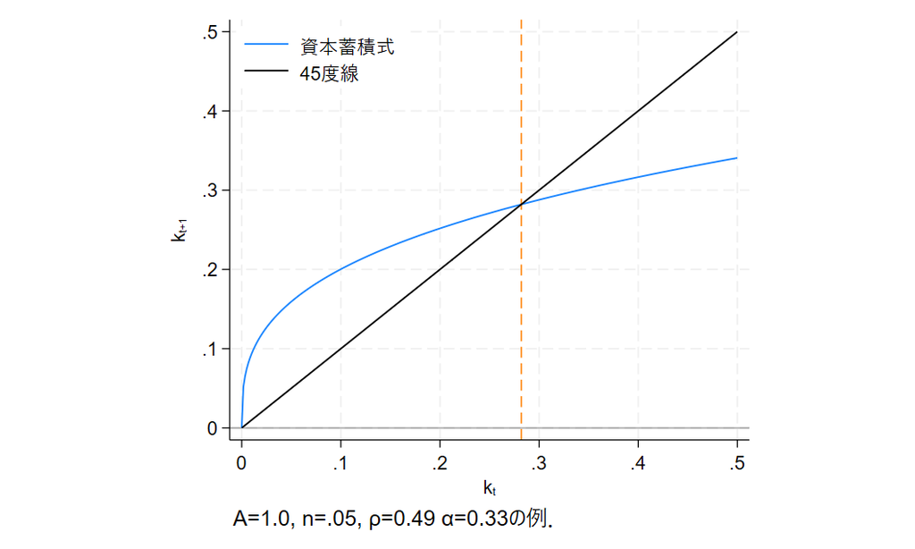

## 定常状態はHappyか？

- 定常状態においては，$s^* = (1+n) k^*$が保たれていないといけない．
- そのもとでは，消費できる量は（一人当たりで測って）
  $$C(k^* ) = f(k^* ) - s^* = f(k^* ) - (1+n)k^*$$

これを最大にする$k^*$を$k^{\rm{g}}$として表すとすれば，
$$C'(k^*) = f'(k^* ) - (1+n) = 0$$
より，$r^* = n$を満たすときに，$k^{\rm{g}}$になると言える．

## 実証的観測

ここでいう，動学的**効率**は，パレート効率の意味．

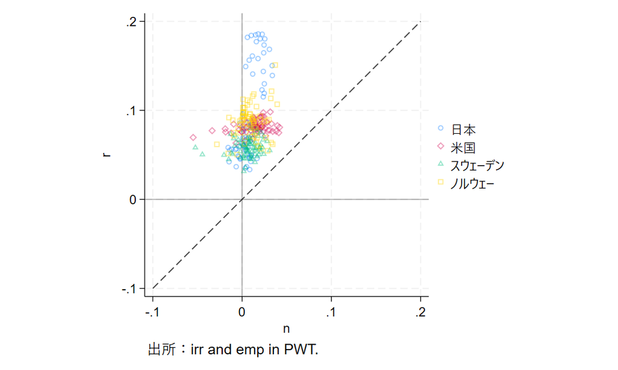

## モデルでの消費最大の条件

議論してきたモデルで議論すると，
$$k^{\rm{g}} = \left( \frac{\alpha A}{1+n} \right)^{\frac{1}{1- \alpha}}$$

いろいろ計算すると，

- $\rho < \frac{1 - 2 \alpha}{\alpha}$なら貯蓄過剰．
- $\rho = \frac{1 - 2 \alpha}{\alpha}$なら，市場均衡は（消費最大の意味で）厚生最大．
- $\rho < \frac{1 - 2 \alpha}{\alpha}$なら貯蓄過少．

$\alpha = 0.33$とすれば，$\rho \approx 1.03$が効率的．

- オイラー方程式で考えれば，めちゃくちゃせっかちなのがわかる．

## 厚生についてのモデル比較

消費最大の基準で厚生を測るならば，（モデルの特定化にもよるが）

- ソローモデルでもラムゼイモデルでも，消費最大をもたらす条件は$r=n$．
  - OLGと同じ．
- ラムゼイモデルでは，常に$r>n$，つまり$k^* < k^{\rm{g}}$が出てくる．
  - 動学的効率．
  - ちょっとややこしい話で，無限視野+横断性条件が絡む．
- OLGはパラメータによって$k^*$は$k^{\rm{g}}$を上回ったり下回ったりもする．
  - もし動学的非効率（$r<n$）なら，社会的には貯蓄を減らすインセンティブがある（年金の議論等）．

# 3 「無限に生きる」家計への接続

## 次世代まで考慮する家計

世代重複モデルの設定を少し変える．

- $t$世代の労働者が1期間労働し，消費し，子供に遺産（$b_{t+1}$）を残す．
  - 子供の効用を考慮している．

このとき，効用関数は次のように設定される．
$$U_t = u (c_t) + \beta U_{t+1}$$

予算制約は
$$\begin{aligned}
c_t + b_{t+1} &= \left( \frac{1+r_t}{1+n} \right) b_{t} + w_t
\end{aligned}$$

- 再帰的な形で表現される．
- 若干違った遺産の取り入れ方（joy-of-giving type）などもあるが，ここでは議論しない．

## 家計のコントロールする変数

- $t$世代の家計は，こ$c_t$と$b_{t+1}$を決める．

$u(c) = \log c$として，

- $U_{t+1} = \log c_{t+1} + U_{t+2}$
- $c_{t}= \left( \frac{1+r_t}{1+n} \right) b_{t} + w_{t} - b_{t+1}$
- $c_{t+1}= \left( \frac{1+r_{t+1}}{1+n} \right) b_{t+1} + w_{t+1} - b_{t+2}$

を代入すると，$c_t$を削除して$b_{t+1}$だけの関数の最大化問題に帰着できる．
$$\begin{aligned}
U_t =& \log \left[ \left( \frac{1+r_t}{1+n} \right) b_{t} + w_{t} - b_{t+1} \right] \\
\hspace{12pt}&+ \beta \log \left[ \left( \frac{1+r_{t+1}}{1+n} \right) b_{t+1} + w_{t+1} - b_{t+2} \right] + \beta U_{t+2}
\end{aligned}$$

## 最適な選択

次の方程式を満たす$b_{t+1}$を選択する．
$$\begin{aligned}
\frac{\partial U_t}{\partial b_{t+1}} =& - \frac{1}{\left( \frac{1+r_t}{1+n} \right) b_{t} + w_{t} - b_{t+1} } \\
\hspace{12pt}&+ \beta \frac{1+r_{t+1}}{1+n} \left[ \frac{1}{ \left( \frac{1+r_{t+1}}{1+n} \right) b_{t+1} + w_{t+1} - b_{t+2}} \right] =0
\end{aligned}$$

変数を置き換えると$c_{t}$の選択として次のような条件式（オイラー方程式）に変形できる．
$$\frac{c_{t+1}}{c_t} = \frac{1+r_{t+1}}{(1+\rho)(1+n) }$$
ただし，$\beta = 1/(1+\rho)$である．

## 定常状態

$c_{t}=c_{t+1}=c^*$，$k_t = k_{t+1} = k^*$のとき定常状態なので，そのとき，
$$(1+\rho)(1+n) = 1+r^* ~ \Longrightarrow \rho + n \approx r^*$$

である．

- $r^*>n$

一方，経済の資源制約は変わらないので，消費を最大にする$k^{\rm{g}}$を達成するには$r^*=n$である必要がある．

- ラムゼイモデルと同様に，競争均衡は常に動学的効率になる．

## 効用関数の変形と「王朝モデル」

議論してきたような，次世代の効用水準からも効用を得るようなモデルは，効用を次のように変形できる．
$$U_0 = u(c_0) + \beta u(c_1) + \beta^2 u(c_2) + \dots = \sum_{t=0}^{\infty} \beta^t u(c_t)$$

つまり，

- 現世代が次世代を気にしている
- 次世代は次次世代を気にしている
- 次次世代は次次次世代を気にしている …

間接的に後続全ての世代の効用を考慮するようなモデルになっている． この意味で，このようなモデルを**王朝モデル**と呼んだりする．

## 補論：$r$ vs $n$ for all country

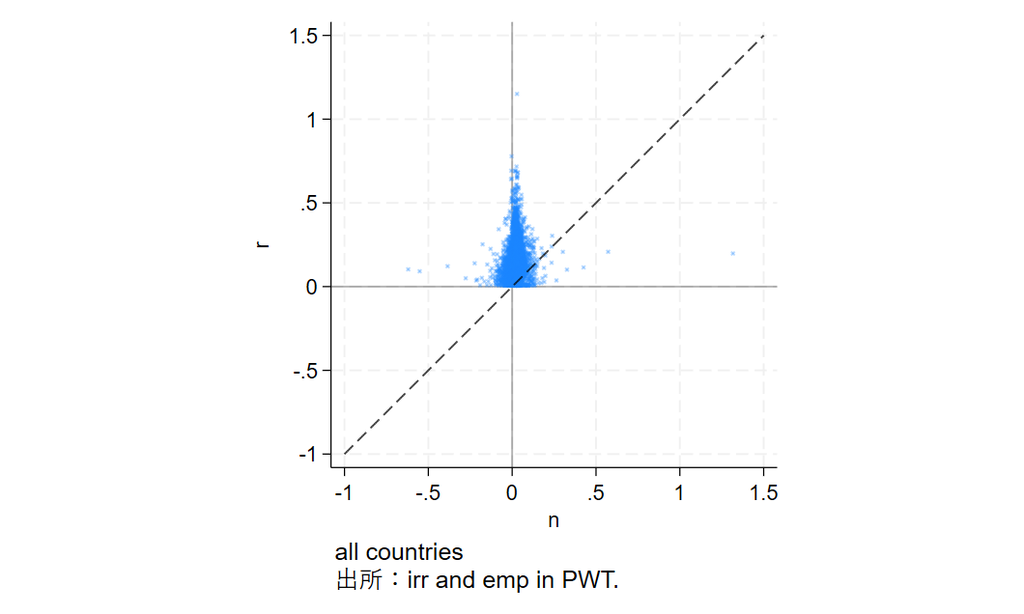